# Overview

# Tour

### Tour

### num_travelers

Total number of people in travel party (maximum at any given point in the tour table)

| Label | Value | Unweighted Count | Weighted Count | Unweighted Percent | Weighted Percent |
| --- | --- | --- | --- | --- | --- |
| 1 traveler | 1 | 12,186 | 7,252,926.5 | 53.4% | 53.6% |
| 2 travelers | 2 | 5,769 | 3,171,888.0 | 25.3% | 23.5% |
| 3 travelers | 3 | 2,896 | 1,827,460.0 | 12.7% | 13.5% |
| 4 travelers | 4 | 1,120 | 569,443.1 | 4.9% | 4.2% |
| 5+ travelers | 5 | 828 | 700,868.3 | 3.6% | 5.2% |
| Missing Response | 995 | 715 | 125,197.1 |  |  |
| Total valid |  | 22,799 | 13,522,585.9 | 100.0% | 100.0% |
| Total missing |  | 715 | 125,197.1 |  |  |
| Total |  | 23,514 | 13,647,783.1 |  |  |

### num_hh_travelers

Number of household members in travel party (maximum at any given point in the tour table)  
if household size > 1

| Label | Value | Unweighted Count | Weighted Count | Unweighted Percent | Weighted Percent |
| --- | --- | --- | --- | --- | --- |
| 1 household traveler | 1 | 13,851 | 7,863,097.63 | 60.8% | 58.4% |
| 2 household travelers | 2 | 5,502 | 3,394,015.40 | 24.1% | 25.2% |
| 3 household travelers | 3 | 2,133 | 1,387,801.70 | 9.4% | 10.3% |
| 4 household travelers | 4 | 958 | 465,746.89 | 4.2% | 3.5% |
| 5 household travelers | 5 | 274 | 214,074.43 | 1.2% | 1.6% |
| 6 household travelers | 6 | 47 | 58,804.44 | 0.2% | 0.4% |
| 7+ household travelers | 7 | 21 | 88,360.82 | 0.1% | 0.7% |
| Missing Response | 995 | 728 | 175,881.77 |  |  |
| Total valid |  | 22,786 | 13,471,901.30 | 100.0% | 100.0% |
| Total missing |  | 728 | 175,881.77 |  |  |
| Total |  | 23,514 | 13,647,783.07 |  |  |

### joint_status

Is this a joint trip or tour with other hh members

| Label | Value | Unweighted Count | Weighted Count | Unweighted Percent | Weighted Percent |
| --- | --- | --- | --- | --- | --- |
| Not Joint | 1 | 13,923 | 7,533,392 | 59.2% | 55.2% |
| Partially Joint | 2 | 5,593 | 3,387,777 | 23.8% | 24.8% |
| Fully Joint | 3 | 3,998 | 2,726,614 | 17.0% | 20.0% |
| Total valid |  | 23,514 | 13,647,783 | 100.0% | 100.0% |
| Total |  | 23,514 | 13,647,783 |  |  |

### tour_category

Tour category

| Label | Value | Unweighted Count | Weighted Count | Unweighted Percent | Weighted Percent |
| --- | --- | --- | --- | --- | --- |
| Individual tour, mandatory travel | 1 | 6,749 | 4,323,096.5 | 28.7% | 31.7% |
| Individual tour, non-mandatory travel | 2 | 12,432 | 6,472,962.4 | 52.9% | 47.4% |
| At-work subtour | 3 | 335 | 125,110.6 | 1.4% | 0.9% |
| Joint tour | 4 | 3,998 | 2,726,613.5 | 17.0% | 20.0% |
| Total valid |  | 23,514 | 13,647,783.1 | 100.0% | 100.0% |
| Total |  | 23,514 | 13,647,783.1 |  |  |

### tour_mode

Primary travel mode for the tour

| Label | Value | Unweighted Count | Weighted Count | Unweighted Percent | Weighted Percent |
| --- | --- | --- | --- | --- | --- |
| Not imputable | -1 | 218 | 18,168.2311 | 0.9% | 0.1% |
| School bus | 1 | 468 | 363,770.2920 | 2.0% | 2.7% |
| Drive to rail | 3 | 193 | 180,554.1614 | 0.8% | 1.3% |
| Drive to bus | 4 | 44 | 47,132.3258 | 0.2% | 0.3% |
| Walk to rail | 6 | 837 | 503,617.8477 | 3.6% | 3.7% |
| Walk to bus | 7 | 591 | 464,574.0888 | 2.5% | 3.4% |
| HOV (3+ people) | 8 | 4,555 | 2,756,316.0174 | 19.4% | 20.2% |
| HOV (2 people) | 9 | 4,539 | 2,569,100.5930 | 19.3% | 18.8% |
| SOV | 10 | 6,675 | 4,447,252.0122 | 28.4% | 32.6% |
| Bike | 11 | 494 | 147,816.4044 | 2.1% | 1.1% |
| Micromobility | 12 | 22 | 3,152.3155 | 0.1% | 0.0% |
| Taxi | 13 | 19 | 12,811.7811 | 0.1% | 0.1% |
| TNC | 14 | 267 | 118,413.7619 | 1.1% | 0.9% |
| Walk | 15 | 4,487 | 1,905,894.8457 | 19.1% | 14.0% |
| Long distance mode | 16 | 6 | 589.3486 | 0.0% | 0.0% |
| Other | 17 | 97 | 106,957.6502 | 0.4% | 0.8% |
| Transit | 18 | 2 | 1,661.3888 | 0.0% | 0.0% |
| Total valid |  | 23,514 | 13,647,783.0655 | 100.0% | 100.0% |
| Total |  | 23,514 | 13,647,783.0655 |  |  |

### tour_purpose

Purpose of the tour

| Label | Value | Unweighted Count | Weighted Count | Unweighted Percent | Weighted Percent |
| --- | --- | --- | --- | --- | --- |
| Not imputable | -1 | 145 | 52,455.12 | 0.6% | 0.4% |
| Work | 2 | 3,348 | 2,455,544.98 | 14.3% | 18.0% |
| Work-related | 3 | 1,525 | 526,061.43 | 6.5% | 3.9% |
| School | 4 | 2,160 | 1,580,191.64 | 9.2% | 11.6% |
| School-related | 5 | 120 | 60,095.30 | 0.5% | 0.4% |
| Escort | 6 | 2,247 | 1,806,820.32 | 9.6% | 13.3% |
| Shop | 7 | 3,490 | 2,102,765.52 | 14.9% | 15.4% |
| Meal | 8 | 1,611 | 608,275.30 | 6.9% | 4.5% |
| Social or recreational | 9 | 2,774 | 1,300,923.69 | 11.8% | 9.5% |
| Errand | 10 | 1,871 | 1,084,454.04 | 8.0% | 8.0% |
| Overnight | 12 | 505 | 259,989.67 | 2.2% | 1.9% |
| Other | 13 | 173 | 246,416.22 | 0.7% | 1.8% |
| Loop | 14 | 3,513 | 1,544,389.29 | 15.0% | 11.3% |
| Missing | 995 | 32 | 19,400.55 |  |  |
| Total valid |  | 23,482 | 13,628,382.52 | 100.0% | 100.0% |
| Total missing |  | 32 | 19,400.55 |  |  |
| Total |  | 23,514 | 13,647,783.07 |  |  |

### partial_status

Whether the person started and/or ended their tour at home

| Label | Value | Unweighted Count | Weighted Count | Unweighted Percent | Weighted Percent |
| --- | --- | --- | --- | --- | --- |
| Complete | 0 | 20,171 | 11,719,304.5 | 85.8% | 85.9% |
| Partial Start | 1 | 1,292 | 787,702.3 | 5.5% | 5.8% |
| Partial End | 2 | 1,310 | 755,033.1 | 5.6% | 5.5% |
| Partial Both | 3 | 741 | 385,743.1 | 3.2% | 2.8% |
| Total valid |  | 23,514 | 13,647,783.1 | 100.0% | 100.0% |
| Total |  | 23,514 | 13,647,783.1 |  |  |

# Using The Data

### Dataset Description

#### **Initial Data Review**

Before reviewing the data for completion, RSG removed households from the dataset that met the following exclusion criteria:

- Household reported a home location outside the survey region.
- Household reported contact information that matches other households (indicating duplicates). In these cases, RSG kept the first “household” to report their travel diary and removed the subsequent records.

#### **Completion Criteria**

To be included in the survey data, a household had to complete the recruit survey and one concurrent day of the travel diary for all participating household members. **All** travel diary information for these households is then included in the survey data, even for days which are partially complete. Because of this, RSG has defined several levels of completeness beyond the household level to help data users filter the tables appropriately.

*Unlinked Trip-level*

The first and simplest level of completion for users to consider is at the unlinked trip level. A trip is complete if the associated trip survey was answered in full. To view trips with completed survey, run the following code:

```r
trip %>% filter(trip_survey_complete==1)
```

*Day-level*

Observations in the day table are also identified as complete or incomplete using the `is_complete` variable. In order for a person’s travel day to be considered complete, they had to:

1. Fill out all of their trip surveys, and
2. Fill out the summary survey for the day (a short series of questions asked at the end of each day, captured by `summary_complete` for adults and `proxy_complete` for children).

It’s important to note that `is_complete` captures whether the day is complete for the associated person. `hh_day_complete` captures whether this same day is complete for all participating household members as well.

```r
# days in which the respondent answered all of their surveys
day %>% filter(is_complete==1)

# days in which all household members answered all of their surveys
day %>% filter(hh_day_complete==1)
```

Users can see how many travel days are complete for each household or person using the `num_days_complete` variable in the household and person tables.

**Note:** Trips can be deleted by the survey participant but restored to the participant’s travel log during manual review. Therefore some complete days may have a small number of incomplete, deleted-then-restored trip surveys.

*Person-level*

A person record is complete if all of their assigned travel days are complete (defined by `is_complete`). Users can see the number of travel days a person has completed using the `num_days_complete` variable in the person table. To see only the complete records in the person table, users can run the following:

```r
person %>% filter(is_complete==1)
```

Several person-level variables were asked in the daily summary surveys, so to determine if there are partially complete person records that could be included in your analysis, check the codebook for which day’s summary survey the variable you’re investigating was asked in. Then use code similar to the following for `transit_freq` to identify which person records are appropriate for your purposes:

```r
# transit_freq is asked in the summary survey on Day 2
complete_2_days = day %>%
  filter(summary_complete==1 &
           day_num==2) %>%
  select(person_id)

# simple frequency table for transit_freq
person %>%
  filter(person_id %in% complete_2_days$person_id) %>%  # filter to only persons with responses to this question
  group_by(transit_freq) %>%
  summarise(n = n())
```

#### **Joining Tables**

The survey data tables contain the following ID columns:

| **Table name** | **Variable(s) to join to other survey data tables** |
| --- | --- |
| Household | hh_id |
| Person | hh_id, person_id |
| Vehicle | hh_id |
| Day | hh_id, person_id, day_id |
| Unlinked Trip | hh_id, person_id, day_id, trip_id, linked_trip_id, tour_id |
| Linked Trip | hh_id, person_id, day_id, linked_trip_id, tour_id |
| Tour | hh_id, person_id, day_id, tour_id |
| Location | trip_id |

The figure below shows how variables can be joined across the eight tables using this series of IDs.

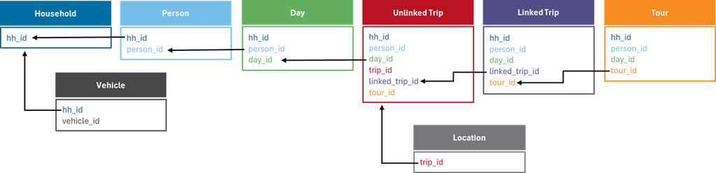

#### **Missing Values**

A survey data table cell may be missing data for one of four reasons:

**1. Value or response is missing due to survey logic, participant non-response, or error.**

*Example:* Participants who traveled by bus were not asked if they were the driver or passenger on the trip.

*Coded as:* 995 for categorical variables, blank/NA for continuous variables

**2. A respondent indicated that the question was not applicable and skipped that question.**

*Example:* Some participants did not share how they pay to park at work because they do not park at work (e.g., carpool).

*Coded as:* 996 (often labeled as “Not applicable”)

**3. A respondent indicated that they didn’t know the answer and skipped that question.**

*Example:* Some participants who made a vehicle trip and paid to park the vehicle may not remember the amount they paid.

*Coded as:* 998 (Don’t know)

**4. A respondent indicated that they preferred not to answer a question and skipped that question.**

*Example:* Some participants chose not to provide their household income.

*Coded as:* 999 (Prefer not to answer)

Other notes about missing survey data:

- For a survey to be complete, all survey questions asked of the participant must have been answered in the app or online instrument.
- Continuous variables (e.g., trip distance, trip duration) are not coded with missing value codes and are instead left empty when missing to avoid interfering with statistical calculations.
- Due to the large size of the location table, missing values were left exactly as they were collected. Speed, heading, and accuracy can all potentially contain missing values that are either stored as “-1”, NA, or 0. Analysis on those fields should filter to where the values are greater than zero.

#### **Geographic Variables**

Census 2020 tract shapefiles were downloaded via the R Tigris package and spatially joined to the reported home, work, school, origin, and destination coordinates. The final reported tract may not always match the tract ascribed to the household’s sample address (which is used to determine the sample segment) for a few reasons:

- Sample addresses are geocoded differently than survey addresses
- Sample addresses sometimes are coded to a mailbox location rather than a home location
- Home addresses in the survey are not always geocoded to a person’s exact home (e.g., a cross street nearby).

Because a person’s reported home address is considered to be more recent and typically more accurate than the sample address, the geographic variables are derived using this address. Households retain their initial sample segment assignment, as this is what determines their probability of being invited according to the information in the sample address file.

All latitude and longitude information in the location table are presented in WGS84 format.

#### **Time and Location Standards**

In this dataset, **timestamps** are stored in two different ways depending on the table:

- Location table: All timestamps are recorded in Coordinated Universal Time (UTC), regardless of where the trip took place.
- Unlinked trip table: Timestamps are recorded in local time (Central Time).

To make the dataset easier to store and transfer across systems, timestamps in the unlinked trip table have been split into separate fields for hour, minute, and second (e.g., `depart_hour`, `depart_minute`, `depart_second` in the trip table). This avoids problems that sometimes occur when software like Microsoft Excel interprets or reformats full datetime objects differently during import/export.

We use this approach because:

- It prevents unexpected shifts caused by daylight savings adjustments or timezone conversions applied automatically by some software (e.g., Microsoft Excel).
- Analysts can reconstruct a full timestamp if needed, or work with the components separately (e.g., for modeling departure-hour effects).
- The UTC standard in the location table allows comparison across different regions (e.g., if a participant recorded a trip that crossed time zones) and avoids ambiguity.

In this dataset, travel days are defined as 24-hour periods from 3 AM to 3 AM. Please note that you should always order the trip table by `person_id` and by `trip_num` or `depart_datetime` (defined below) to see a person’s travel roster. It is not reliable to order by `trip_id`.

*Reconstructing Timestamps in R*

You can recombine the split fields into a full time object using `lubridate::make_datetime()` or `hms::hms()`. For example:

```r
library(lubridate)

# Suppose you have columns: depart_date, depart_hour, depart_minute, and depart_second
trips$depart_datetime <- make_datetime(
  year  = year(trips$depart_date),
  month = month(trips$depart_date),
  day   = day(trips$depart_date),
  hour  = trips$depart_hour,
  min   = trips$depart_minute,
  sec   = trips$depart_second,
  tz    = "America/Chicago" # Central time for trip table
)
```

*Tips For Working With Timestamps*

- **Time zone alignment:** If you merge location data (UTC) with trip data (Central), convert one set so they are in the same time zone before analysis.
- **Daylight savings time:** When reconstructing local times, be careful about DST changes—lubridate handles this if the correct tz is set.
- **Aggregation by time of day:** If you only care about the hour of travel (e.g., peak vs. off-peak), you may not need to recombine full timestamps.

#### **Outliers**

Continuous variables (e.g., trip distance, trip duration) in the dataset may contain outliers. *Data users should be aware of these outliers when calculating summary statistics (e.g., mean) for any variables identified as ‘numeric’ in the Data Type field of the codebook.*

To assist data users with identifying such outliers, three variables have been included in the trip table: flag_speed, flag_distance, and flag_duration. These flags were defined for single-mode trips only, with modes grouped into the following categories for the purpose of adding these flags. For these single-mode trips, modified z-scores were calculated within each mode category for speed_mph, distance_miles, and duration_minutes. (Modified z-scores use the median instead of the mean, and are therefore more suitable for the right-skewed distributions seen here.) The cut-offs for these z-scores used to identify outliers in a given variable/mode combination are shown in the table below.

| **Single-mode group** | **mode_1 values** | **Cut-off for speed z-scores** | **Cut-off for distance z-scores** | **Cut-off for duration z-scores** |
| --- | --- | --- | --- | --- |
| Walk | 1 | 4 | 4 | 4 |
| Standard bicycle | 2,3,4,69 | 3 | 3 | 3 |
| E-bicycle/scooter | 74,77,82,83 | 3 | 3 | 3 |
| Vehicle | 6,7,8,9,10,11,12,13,14,15,16,17,18,21,22,33,34, 36,37,47,49,50,54,59,60,76,504,505,506 | 3 | 4 | 4 |
| Bus | 501,502,511,513 | 3 | 3 | 3 |
| Rail | 507,508,509,510,512,514 | 3 | 3 | 3 |
| Other | 5,24,31,32,43,44,45,75,80,81 | 4 | 4 | 4 |

When working with other continuous numeric variables in the data, one approach for identifying outliers is to use a high quantile:

```r
library(stats)
library(dplyr)

hours_worked_cutoff = quantile(person$hours_worked, 0.975, na.rm=TRUE)

# mean hours worked without outliers
person %>%
  filter(hours_worked <= hours_worked_cutoff) %>%
  summarize(mean_hours_worked = mean(hours_worked, na.rm = TRUE))
```

#### **Derived and Recoded Variables**

This dataset includes a combination of variables that were actively collected via survey questions, passively collected via rMove or other metadata, implicitly assigned (e.g., administrative variables such as ID numbers), and derived or recoded (calculated from some combination of other variables). Key derived or recoded variables in this dataset are summarized below.

*Household-level Variables*

- Completion status
- Home tracts
- Aggregate income (based on the initial and follow-up income questions)

*Person-level Variables*

- Completion status
- Number of complete days
- Work/school tracts

*Day-level Variables*

- Completion status
- Number of trips per day

*Trip-level Variables*

- Trip path distance (based on the GPS location data)
- Trip speed
- Departure time (imputed in some cases)
- Trip purpose (imputed in some cases)
- Mode type and purpose categories
- Access and egress flags
- Trip origin and destination tracts

#### **Location Anonymization Process**

To avoid disclosing overly sensitive PII, an anonymization process was applied to the location data during trip processing. A trip’s origin point, as well as any subsequent points continuously captured in the origin’s Census tract, was anonymized to the centroid of the origin tract. However, if the trip left the origin tract and then temporarily re-entered the origin tract, the point data would not be anonymized.

Similarly, the destination point was also anonymized to the centroid of the destination’s tract, barring the circumstance that the trip passed through the destination tract prior to the trip’s final entry to the tract on the way to the final destination. The following illustration demonstrates this logic.

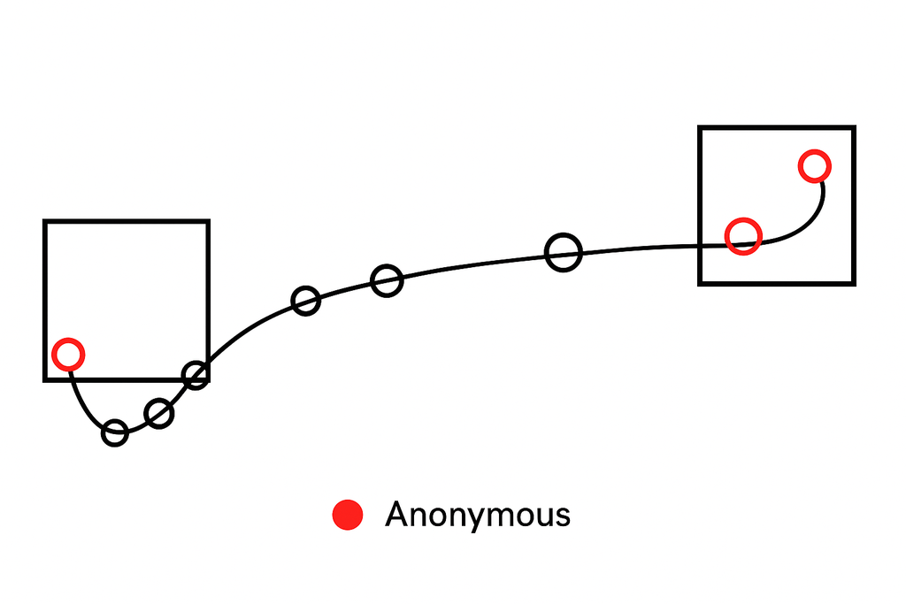

### Unlinked Trip Processing

#### **Manual Trip Editing**

Trips that are marked for review in the trip classifier are reviewed by analysts while other trips are automatically kept or dropped from the dataset. Analysts will then split, merge, and drop trips. Manual trip editing occurs as follows:

- A trip is split if there is a change of mode, a large dwell time, or if at least some of the trip is within a destination (e.g., hospital, gas station)– these trips are split and then dropped.
- A trip is merged if there is a small or nonexistent dwell between trips.
- A trip is dropped if it is within a destination.

#### **Trip Purpose, Location, and Departure Time Cleaning**

*Purpose and Location*

Respondents report the purpose of the trip destination in each trip survey. The origin purpose is derived from the destination purpose of the previous trip, except for the first trip in the travel period or where an rMove™ trip occurs after a trip with item non-response. For the first trip in the travel period, the origin purpose can be inferred from `begin_day` in the day table.

When purpose was not asked because an analyst split a user-reported trip during data cleaning (creating a new destination along a trip), purpose values are derived where possible based on proximity (within 150 meters) to estimated home, work, or school locations. If the location is not proximate to home, work, or school locations, the purpose is set to other.

Trip purposes have been imputed in cases where a purpose reported by the user is assumed to be inaccurate based on information about that person’s reported habitual locations and other trips (primarily to home, work, and school locations). The trip purpose imputation approach was applied to all rMove™ trips in person-days with at least 1 complete trip and no more than 10 incomplete trips. (Incomplete trips are trips for which the respondent did not answer the trip-specific survey questions about purpose, mode, etc. for the given trip.)

The approach was to apply various tests in logical sequence to trips for which the stated purpose is not consistent with the location type based on the reported habitual locations. In general terms, the tests were designed to:

- Check the respondent’s reported destination purpose when it conflicts with the destination location type. (The details of the tests depend on the trip purpose, with different criteria used for change-mode trips, escort trips, linked transit trips, trips with home destinations but other reported purposes, etc.)
- Identify cases where respondents swapped the order of two or more trips when reporting their details.
- Identify cases where respondents may have omitted a trip and shifted remaining reported trip details by one trip when reporting the rest of their trips.
- Fill in missing data by sampling destination purposes from other trips made to the same locations, either by the same respondent or by other respondents.

*Departure Time*

In some cases, the rMove app may have detected the start of a trip after its true start time, which can yield invalid or extreme values for trip duration and speed. In these cases, the fields `depart_date`, `depart_hour`, and `depart_minute` were adjusted for “late pickup” conditions using the following approach:

- Departure time was imputed using the median speed between all locations along the trip, excluding the origin point, and the distance between the origin and the next point on the trip. For trips with fewer than three recorded locations, imputed departure time is set three minutes earlier than the original departure time to compensate for rMove’s 3-5-minute ping interval. Note that some trips that are the result of split loop trips may only have three or fewer points but will use the imputed depart time from before the loop trip was split and thus may not be included in this rule.
- If the imputed departure time overlaps with the previous trip’s arrival time, the previous trip’s arrival time was instead used as the departure time. Regardless of the number of locations along a trip, if the imputed departure time was later than the initially reported departure time, the imputed departure time is set to the original departure time. User-added trips as well as long distance passenger mode trips are also set to the original departure time, as user-added trips are not subject to “late pickup” conditions, and long-distance passenger modes are often plane trips where all collected traces contain speed information from other modes and thus are less reliable (as rMove cannot collect locations when a phone is in “airplane mode”).

Duration and speed are calculated based on the imputed departure time.

#### **Purpose Categories**

Purposes are up coded (e.g., `d_purpose_category` and `o_purpose_category`) to purpose categories guided by the questionnaire for convenience. A full crosswalk of purposes and purpose categories are shown below. Note that `d_purpose_category` can include imputed values for trips, whereas `d_purpose_category_reported` is the up coded value according to the `d_purpose_reported`, directly from the participant’s survey response.

| Detailed Purpose | Detailed Purpose Value | Purpose Category | Purpose Category Value |
| --- | --- | --- | --- |
| Went home | 1 | Home | 1 |
| Went to primary workplace | 10 | Work | 2 |
| Went to work-related activity (e.g., meeting, delivery, worksite) | 11 | Work related | 3 |
| Volunteering | 13 | Work related | 3 |
| Other work-related | 14 | Work related | 3 |
| Attend K-12 school | 21 | School | 4 |
| Attend college/university | 22 | School | 4 |
| Attend other type of class (e.g., cooking class) | 23 | School | 4 |
| Attend daycare or preschool | 26 | School | 4 |
| Attend other education-related activity (e.g., field trip) | 24 | School related | 5 |

[output cut: 29 more lines]

#### **Mode Priority & Mode Types**

The mode information reported by respondents and captured in `mode_1` through `mode_6` is synthesized down to a single, easier-to-use variable `mode_priority` so that data users can avoid always referencing all modes on a multimodal trip. This is done using a prioritization of the modes, developed in partnership with CMAP. This `mode_priority` variable has the same large number of value labels as `mode_1`, and so `mode_type` has been defined to collapse the specific modes into categories.

The table below shows the full crosswalk of which detailed modes correspond to which mode types, and the ‘Importance’ column shows the ranking used to define `mode_priority`. When transit trips were unlinked using the Google API during cleaning (and thus did not have a reported `mode_1` - `mode_6`), the non-transit legs of the trip were recoded using Google’s suggested mode (most frequently “walk” or “bike”) and do not have a reported `mode_1` - `mode_6`.

| Detailed Mode | Detailed Mode Value | Mode Type | Mode Type Value | Importance |
| --- | --- | --- | --- | --- |
| Walk (or jog/wheelchair) | 1 | Walk | 1 | 1 |
| Skateboard or rollerblade | 43 | Walk | 1 | 2 |
| Standard bicycle (my household's) | 2 | Bike | 2 | 3 |
| Borrowed bicycle (e.g., a friend's) | 3 | Bike | 2 | 4 |
| Other rented bicycle | 4 | Bike | 2 | 5 |
| Divvy bike | 69 | Bike | 2 | 6 |
| Electric bicycle (my household's) | 82 | Bike | 2 | 7 |
| Segway | 74 | Scooter Share | 4 | 11 |
| Scooter-share (e.g., Lime) | 83 | Scooter Share | 4 | 10 |
| Regular taxi | 36 | Taxi | 5 | 12 |

[output cut: 48 more lines]

#### **Distance Variables**

The distance information for given unlinked trip is captured in four different variables:

- `distance_meters_beeline` - The straight line distance between the trip’s origin and destination.
- `distance_meters_app` - The trace distance of a trip captured in rMove. Note that trips reported online or by the call center, AND trips manually added by rMove participants (not detected by the app) will not have a value for this variable.
- `distance_meters` and `distance_miles` - The trace distance for rMove trips, otherwise this is the routed trip distance between the origin and destination.

Both `distance_meters` and `distance_miles` are also available in the linked trip and tour tables, and are calculated as the summation of the distances of the component unlinked trip legs.

### Trip Unlinking

#### **Trip Unlinking**

The trip unlinker is run on trips that have no auto mode and do have a bus or rail mode The trips are queried through Google to identify the path with the best overlap of the collected points. Trips are then split by the results of the unlinker into their component “unlinked” trip legs (typically an access, transit, and egress trip). If a trip was split in manual trip editing, the directions will be deleted and the trip will be re-routed based on the new start/stop points.

#### **Synthetic Trips**

Synthetic trips are created for transit trips that are missing an access/egress leg. These trips have distance and duration set to NULL (to avoid skewing summary statistics). These trips identify where we know that there was a trip, but we are unsure of the details. Synthetic access trips will have the same depart and arrive time as the depart time for the subsequent trip and the same origin/destination as the origin of the subsequent trip. Synthetic egress trips will have the same depart and arrive time as the arrive time of the prior trip and the same origin/destination as the prior trip’s destination.

To identify these synthetic trips, filter the unlinked trip table using the `transit_quality_flag` variable:

```r
# the codebook shows the synthetic access and egress values are 1 and 2, respectively
trip %>% filter(transit_quality_flag %in% 1:2)
```

#### **Linked Modes and Purposes**

`linked_trip_mode` is defined for the linked trip table using the `mode_priority` values of the linked trip’s component unlinked legs, and applying the same importance ranking process that was used to define `mode_priority` from `mode_1` - `mode_6` in the unlinked trip table (see Mode Priority & Mode Types under Unlinked Trip Processing).

`o_purpose` and `d_purpose` for linked trips are defined as the origin purpose of the first unlinked trip leg and the destination of the last unlinked trip leg, respectively.

### Joint Trip & Tour Creation

#### **Joint Trip Detection & Imputation**

To identify and impute missing joint trips, RSG first performs a joint trip detection process to match trip records across household members. Because smartphones traveling at the same time may detect information slightly differently, this process is not exact. User-added trips (which may include inexact times and locations) add to the complexity. To best match trips across members, RSG uses a threshold of trips that depart/arrive less than 15 minutes apart and start/end from locations under 100 meters away. From this group, a list of trip pairs forms a network graph that can be used to identify unique joint trips as being a fully connected subgraph clique (i.e., two or more trips that completely overlap with each other).

Once all trips are associated into sets of unique joint trips, the missing joint trips can be identified as the difference between the number of joint trip records and the total reported household members in a unique joint trip. For example, if a joint trip has only three trip joint records but the joint trips report four household members, then one trip record is missing.

These missing trips can then be imputed by copying the trip attributes from a host trip. The host is determined as the person with the lowest person number in the household. The one caveat is that the trip purpose cannot always be imputed if the purpose of host trip is “escort”, which is common for missing child trips. To mitigate this, purpose is imputed if the destination is a known fixed location, such as home or school. A buffer radius of 100 meters is used to check if the destination is associated with one of those known fixed locations.

#### **School Trip Detection & Imputation**

School trip imputation takes place after joint trip imputation. School trip imputation is necessary due to significant underreporting of school attendance in raw survey data, especially among children. Previous studies indicate that only 40 to 50% of students are reported as attending school on a typical weekday, which contrasts sharply with the expected attendance rates of 80% to 90%. This discrepancy largely arises because children under eighteen do not participate directly in travel surveys; instead, their travel is reported by a proxy adult within the household. Consequently, child trips – particularly those not accompanied by the reporting adult – are more likely to be missed than adult trips. The travel survey included targeted questions for the proxy reporter about if the child attended school that day, if the location was different from their primary school, and their typical travel mode.

School trips are imputed when survey responses indicate the student attended school, but the student has missing trips to or from school. Imputed school trips have their start and end times sampled from the existing school trip distribution. School locations and usual mode to/from school are reported separately and can therefore be used to determine the location and mode category of the trip. Further attributes such as disaggregate mode, vehicle occupancy, and driver status are also drawn from a random distribution built upon existing survey reports. If the proxy reports that the child attended school at a different location, imputation is not possible because the destination is unknown. Similarly, children identified as home-schooled or non-students are excluded from school trip imputation. This logic ensures that only plausible school trips are added to the travel dataset, improving completeness without introducing inaccurate records.

#### **Tour Organization**

A tour consists of a sequence of linked trips for a person on a given day and is delineated whenever the location is “home” (e.g., the person leaves home or arrives home) or a new day starts, with a day start time typically set at 3:00AM. This means it is possible for someone to start or end a tour not at their “home” location if a person does not return home in that time window, or the survey starts mid-tour. If either end of a tour is not “home”, then the tour is considered a partial tour.

After all joint trip detection and trip imputation is performed, the data is sent to be formed into tours. This includes the linking of unlinked trips into linked trips and grouping those linked trips into tours that start and end at home (or at work for at work subtours). Joint travel between household members at the tour level is determined as is explicit escorting involving the dropoff or pickup of household members. Attributes for persons, tours, and trips are created that allow for easy comparison to activity-based model outputs. Those outputs then summarized and visualized for aggregate level summaries for QA/QC.

### Working with Weights

#### **Introduction**

This section demonstrates how to generate weighted frequencies of the single-choice categorical variables in the dataset, including margins of error for the estimates. For this example, we’ll use `transit_freq` to create a summary table.

*Why would there be missing responses?*

There may be missing responses to variables in the data for a few reasons:

- This question did not apply to the participant or was not relevant for them (e.g., asking someone who is not employed what industry they work in). Users should check the `logic` column in the codebook to find which participants were asked the question you’re analyzing.
- This participant did not get to this question before their survey period expired. As outlined under Completion Criteria in the Dataset Description section, in order to be included in the final dataset households had to have completed one concurrent day of their travel diary. Therefore, if the question being analyzed was asked on one of the days that a household did not fully answer, then the response may be missing for this household/person/day/etc.

In this case, `transit_freq` was asked of all participants in the second daily survey, so to see which respondents should have values for this variable you can use the following:

```r
transit_freq_persons = day %>%
  filter(is_participant==1) %>%
  filter(day_num==2 & is_complete==1) %>%
  select(person_id)
```

*Why would there be missing weights?*

Households who complete one concurrent day of their travel diary have **all** of their data included in the final dataset, and therefore there are varying levels of completeness for each table in the dataset.

- **Household** - All households in the dataset will have household weights.
- **Vehicle** - All vehicles in the dataset will have household weights.
- **Person** - Non-participants (household members not related to person 1) were not weighted.
- **Day** - Days in which all of the trip surveys and the summary/proxy survey were not answered by all household members were not weighted.
- **Trips and Tours** - Unlinked trips, linked trips, and tours will be missing their respective weights if the associated trip survey was not completed, or if the associated travel day was not fully completed.

#### **Generate Frequency Table**

Let’s start by looking at a simple count of the responses, filtering to the participants who we’ve identified should have answered this question:

```r
person %>%
  filter(person_id %in% transit_freq_persons$person_id) %>%
  group_by(transit_freq) %>%
  summarize(count = n()) %>%
  ungroup() %>%
  mutate(percent = round(count / sum(count),3))
```

```
# A tibble: 9 × 3
  transit_freq count percent
         <int> <int>   <dbl>
1            1    51   0.041
2            2    65   0.052
3            3    46   0.037
4            4    81   0.065
5            5    76   0.061
6            6    57   0.045
7            7   139   0.111
8            8   385   0.307
9          996   353   0.282
```

To make this table more readable, you can create a factor by pulling in the value labels for `transit_freq` from the codebook:

```r
# Pull value labels for transit_freq
transit_freq_labels = value_labels %>% filter(variable=='transit_freq')

# Create a new factored variable using these labels
person = person %>%
  mutate(
    transit_freq_f = factor(
      transit_freq,
      levels = transit_freq_labels$value,
      labels = transit_freq_labels$label
    )
  )

# Generate summary of the factored variable
person %>%
  filter(person_id %in% transit_freq_persons$person_id) %>%
  group_by(transit_freq_f) %>%
  summarize(count=n()) %>%
  ungroup() %>%
  mutate(percent = round(count / sum(count),3))
```

```
# A tibble: 9 × 3
  transit_freq_f    count percent
  <fct>             <int>   <dbl>
1 6-7 days a week      51   0.041
2 5 days a week        65   0.052
3 4 days a week        46   0.037
4 3 days a week        81   0.065
5 2 days a week        76   0.061
6 1 day a week         57   0.045
7 1-3 days a month    139   0.111
8 Less than monthly   385   0.307
9 Never               353   0.282
```

Now let’s calculate the weighted proportions for this variable. Instead of counting the rows, we simply sum the weights:

```r
person %>%
  filter(person_id %in% transit_freq_persons$person_id) %>%
  group_by(transit_freq_f) %>%
  summarize(count = sum(person_weight)) %>%  # switched from count = n()
  ungroup() %>%
  mutate(percent = round(count / sum(count),3))
```

```
# A tibble: 9 × 3
  transit_freq_f      count percent
  <fct>               <dbl>   <dbl>
1 6-7 days a week    54948.   0.048
2 5 days a week      70342.   0.061
3 4 days a week      45803.   0.04
4 3 days a week      54098.   0.047
5 2 days a week      55900.   0.048
6 1 day a week       48022.   0.042
7 1-3 days a month  120260.   0.104
8 Less than monthly 330624.   0.286
9 Never             375469.   0.325
```

To calculate standard errors for these percentages, you can use the `srvyr` package to define a design object. Then you create your summary from the design object instead of the original table, and use the `survey_prop()` function to generate proportions with errors:

```r
library(srvyr)

# Define the design
person_design = person %>%
  as_survey_design(
    ids = person_id,
    weights = person_weight
  )

# Create weighted frequency with errors
person_design %>%
  filter(person_id %in% transit_freq_persons$person_id) %>%
  group_by(transit_freq_f) %>%
  summarize(count = sum(person_weight),
            percent = survey_prop(vartype = 'se', propotion = TRUE))
```

```
# A tibble: 9 × 4
  transit_freq_f      count percent percent_se
  <fct>               <dbl>   <dbl>      <dbl>
1 6-7 days a week    54948.  0.0476    0.0123
2 5 days a week      70342.  0.0609    0.0129
3 4 days a week      45803.  0.0396    0.00955
4 3 days a week      54098.  0.0468    0.00978
5 2 days a week      55900.  0.0484    0.00963
6 1 day a week       48022.  0.0416    0.00889
7 1-3 days a month  120260.  0.104     0.0146
8 Less than monthly 330624.  0.286     0.0208
9 Never             375469.  0.325     0.0228
```